# PostGIS

Jan-Philipp Kolb

Fri Aug 28 10:07:51 2015

## Starting Point

- [Setting up a local copy of osm](http://wiki.openstreetmap.org/wiki/Setting_up_a_local_copy_of_the_OpenStreetMap_database,_kept_up_to_date_with_minutely_diffs)

## Why PostGIS

- [PostGIS and R](http://gis.stackexchange.com/questions/64950/which-is-the-best-way-of-working-with-postgis-data-in-r)

[figure not shown]

## Get started

- [Getting started tutorial](http://www.bostongis.com/?content_name=postgis_tut01)
- [Download of Postgresql](http://de.enterprisedb.com/products-services-training/pgdownload)
- [Get started](http://km-bw.de/site/pbs-bw/get/documents/KULTUS.Dachmandant/KULTUS/Dienststellen/it.kultus-bw/pdf/SVP_BW/Postgres_Datenbankinstallation.pdf) with pgAdmin III.

## [Create a database](http://learnosm.org/en/osm-data/setting-up-postgresql/)

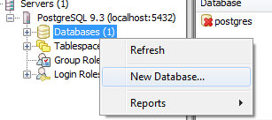

[figure not shown]

## Setup PostGIS

- Hints on the setup of [PostGIS](http://wiki.openstreetmap.org/wiki/Osmosis/PostGIS_Setup) and [PostGIS windows setup](http://wiki.openstreetmap.org/wiki/DE:Postgis92_Win7_64bit)
- Just create a database and then on the SQL view in pgAdmin, [type and run:](http://gis.stackexchange.com/questions/26508/how-to-create-postgis-template)

```bash
CREATE EXTENSION postgis;
```

## Import of OSM data

General methods:

- [Installer](http://gis.stackexchange.com/questions/118334/download-link-to-osm2pgsql) for [osm2pgsql](http://learnosm.org/en/osm-data/osm2pgsql/)
- [Use python program imposm](http://imposm.org/)
- [Import PostGIS](http://www.postgis.us/Presentations/PGOpen2014_Session1.html#/)
- [Intro imposm](http://imposm.org/docs/imposm/latest/tutorial.html)

Methods for windows

- [pgshapeloader](http://suite.opengeo.org/4.1/dataadmin/pgGettingStarted/pgshapeloader.html) - [how it works](http://suite.opengeo.org/4.1/dataadmin/pgGettingStarted/pgshapeloader.html)
- [osmosis](http://skipperkongen.dk/2012/08/02/import-osm-data-into-postgis-using-osmosis/)
- [shp2pgsql](http://gis.stackexchange.com/questions/50107/where-to-find-shp2pgsql-windows-binaries)
- Overview of import and export [methods](http://manual.linfiniti.com/en/postgis/import_export.html)

## Work with shp2pgsql

- To use the command `psql` [set a path variable](https://support.microsoft.com/de-de/kb/310519)
- [Documentation](http://www.postgresql.org/docs/9.4/static/app-psql.html) command `psql`

```bash
shp2pgsql -I -s 900913 D:/Daten/Daten/GeoDaten/bremen-140226.shp/points.shp
public.geospatial-data | psql -p 5432 -d RLPgis
```

```bash
shp2pgsql -I -s 900913 D:/Daten/Daten/GeoDaten/rheinland-pfalz-latest.shp/roads.shp public.geospatial-data | psql -p 5432 -d RLPgis2
```

## [Work with psql](http://stackoverflow.com/questions/15618530/how-can-i-get-all-roads-ways-from-an-osm2pgsql-shema)

```bash
psql RLPgis2
```

## Work with osm2psql

- [Get started with osm2psql](http://learnosm.org/en/osm-data/osm2pgsql/)

```bash
osm2pgsql -c -d BWgis -U kolbjp -H localhost -S D:\Daten\Daten\GeoDaten\default.style D:\Daten\Daten\GeoDaten\baden-wuerttemberg-latest.osm.pbf
```

```bash
osm2pgsql germany-latest.osm.bz2 -d GermanyOSM -U kolbjp -P 5432 -S D:\Daten\Daten\GeoDaten\default.style --hstore
```

- [install legacy.sql](https://github.com/springmeyer/win-osm-workshop/blob/master/Tutorial.md#step-6-configure-the-osm-postgis-database)

```bash
C:\Program Files\PostgreSQL\9.4\share\contrib\postgis-2.1
```

```bash
osm2pgsql -d SALgis -U kolbjp -H localhost -S D:\Daten\Daten\GeoDaten\default.style -p osm -l -s -c saarland-latest.osm.bz2
```

## PostgreSQL queries

- [PostgreSQL queries](http://www.postgresql.org/docs/8.1/static/queries.html)
- [Querying data](http://www.bostongis.com/PrinterFriendly.aspx?content_name=postgis_tut01)

```sql
SELECT "geospatial-data".osm_id FROM public."geospatial-data";
```

[Get ordered results:](https://www.digitalocean.com/community/tutorials/how-to-create-data-queries-in-postgresql-by-using-the-select-command)

```sql
SELECT
  "geospatial-data".type,
  "geospatial-data".osm_id
FROM
  public."geospatial-data"
ORDER BY
  "geospatial-data".type
;
```

Get filtered results:

```sql
SELECT
  "geospatial-data".type,
  "geospatial-data".osm_id
FROM
  public."geospatial-data"
WHERE
  "geospatial-data".type = 'advertising'
;
```

```sql
SELECT
  "geospatial-data".type,
  "geospatial-data".osm_id
FROM
  public."geospatial-data"
WHERE
  "geospatial-data".type LIKE 'a%'
;
```

## PostGIS

- [Manual](http://postgis.net/docs/)
- [Spatial queries](http://manual.linfiniti.com/en/postgis/spatial_queries.html)
- [Understanding PostGIS Spatial Queries](http://www.gistutor.com/postgresqlpostgis/10-intermediate-postgresqlpostgis-tutorials/75-understanding-postgis-spatial-queries.html)

## Back to R

- [Getting started with PostgreSQL in R](https://datashenanigan.wordpress.com/2015/05/18/getting-started-with-postgresql-in-r/)

```r
require("RPostgreSQL")
pw <- {"xyz"}
drv <- dbDriver("PostgreSQL")
# and so on
```

- [PostGIS and R](https://fenix.tecnico.ulisboa.pt/downloadFile/3779576719789/introducao-PostGIS.pdf)

## More info about PostGIS and R

- [How to make R, PostGIS and QGis cooperate](https://hal.inria.fr/file/index/docid/737397/filename/bonin_V2.pdf)

```r
require(rgdal)
dsn="PG:dbname='gisdb'"
ogrListLayers(dsn)
```

- [Getting started with PostgreSQL in R](https://datashenanigan.wordpress.com/2015/05/18/getting-started-with-postgresql-in-r/)

## Additional information

- [Standard Ports](https://de.wikipedia.org/wiki/Liste_der_standardisierten_Ports)
- [Solution](http://gis.19327.n5.nabble.com/osmosis-dev-Codehaus-discontinued-Osmosis-not-working-td5847581.html) for problem with running osmosis
- [Intro PostGIS](https://wiki.postgresql.org/images/7/7d/2011-11-11_pg.conf.de_darf_ich_vorstellen_postgis_aemde.pdf)
- [Intro GeoServer and PostGIS](http://blog.geoserver.org/2009/01/30/geoserver-and-openstreetmap/)
- [Cartography with TileMill, PostGIS and OpenStreetMap](https://www.youtube.com/watch?v=rUfj993tPUo)
- [PostGIS Initialization](http://forum.openstreetmap.org/viewtopic.php?id=21810)

Google Searches

r-project + postgis

```r
# http://postgis.net/

# http://gis.stackexchange.com/questions/64950/which-is-the-best-way-of-working-with-postgis-data-in-r
require(rgdal)
library("intamap")
```

## Resources

- [First steps](http://doc.postgres.de/postgresql_9.0/tutorial-createdb.html)
- [OSM and PostGIS](http://cnr.ncsu.edu/geospatial/wp-content/uploads/sites/6/2014/08/Zielstra_Tonini_021215.pdf)
- Set up PostGIS database
- PostGIS [Boundless workshop](http://workshops.boundlessgeo.com/postgis-intro/)

## Work with osmosis

- [Learn osmosis](http://learnosm.org/en/osm-data/osmosis/)
- Work with [osmosis](http://wiki.openstreetmap.org/wiki/User:Ajoessen/Osmosis)
- [detailed usage osmosis](http://wiki.openstreetmap.org/wiki/Osmosis/Detailed_Usage_0.43)

```bash
osmosis --rbf sample_osmosis.osm.pbf --write-xml sample.osm
```

```bash
osmosis --rbf rheinland-pfalz-latest.osm.pbf --write-xml RLP.osm
```

- [postgis](https://gist.github.com/jpetazzo/5177554)
- [Three tools explained](https://me4bruno.wordpress.com/2012/03/25/osmosis-osm2postgresql-osm2pgsql-openstreetmap-daten-datenbanken-und-spielplatze/)

```bash
osmosis --read-xml "D:\Daten\Daten\GeoDaten\germany-latest.osm.bz2" --write-pgsimp database="GermanyOSM"  user="kolbjp"
```

```bash
osm2pgsql -c -d GermanyOSM -U kolbjp -W --latlong -H localhost D:\Daten\Daten\GeoDaten\germany-latest.osm.bz2 --style D:\Daten\Daten\GeoDaten\default.style
```

## Links

[Zielstra - PostGIS](https://cnr.ncsu.edu/geospatial/wp-content/uploads/sites/6/2014/08/Zielstra_Tonini_021215.pdf)

[Data into postgresql](http://skipperkongen.dk/2011/01/20/how-to-import-open-street-map-data-into-postgresql/)

[Setting up postgresql](http://learnosm.org/en/osm-data/setting-up-postgresql/)